# Natural Vibration estimations

## Initial data entry & libraries import

We are using **matplotlib** for the plotting as well as **numpy** for the data analysis.

The three estimation methods, computed in an excel sheet were based on:

1. the reader given for the project
2. http://www.mse.mtu.edu/~drjohn/my4150/sandwich/sp1.html
3. https://research.tue.nl/en/publications/optimization-of-the-bending-stiffness-and-strength-of-compoiste-s

The weights are the weights of the panels *without the added payload*, which is a fixed weight of 5kg, but it is included in the vibration calculation.

```python
%matplotlib inline
import matplotlib as mpl
import matplotlib.pyplot as plt
import numpy as np
from matplotlib import patches
from matplotlib.collections import PatchCollection
from matplotlib.ticker import FormatStrFormatter
plt.style.use("seaborn")

# values = [[7.37863777,7.16135244,6.68018659],
# [8.36216826,8.21797906,7.54730161],
# [9.28343582,9.24003235,8.36163268],
# [12.0524465,11.6661051,10.8696634],
# [13.5456823,13.3019256,12.2031687],
# [14.917841,14.8554275,13.4297178],
# [5.90474892,5.72770807,5.36906372],
# [6.95595396,6.83987604,6.28665507],
# [9.1741596,8.81561165,8.46273745],
# [10.7161468,10.3375408,9.79113002],
# [13.0577002,13.6603037,13.3517087],
# [15.1884718,15.41947,14.9268507],
# [8.73594982,8.41288292,7.93343768],
# [9.8711002,9.59997682,8.93120301],
# [10.9270176,10.7386026,9.86221459],
# [14.2702998,13.679029,12.8838235],
# [15.9910276,15.5160405,14.4186051],
# [17.5603118,17.2443111,15.8199079],
# [20.8640332,19.9322118,19.4685544],
# [23.3584351,22.2533336,21.6029765],
# [25.6232986,24.4110873,23.5554761],
# [34.0983654,31.8692677,31.0864028],
# [37.8625824,35.489802,34.4068487],
# [41.2060904,38.7723958,37.3643306]]

weight = [263.4,319,374.6,665,821,977,151.25,188,175.85,212.6,222.75,259.5,
          271.6,327.2,382.8,673.2,829.2,985.2,345.4,401,456.6,747,903,1059]

titles = ["Al panel + aramid core (10mm)", "Steel panel + aramid core (10mm)",
          "CF panel + aramid core (10 & 16mm)", "CF panel + foam core (22.5mm)",
          "Al panels + Al core (12 & 30 mm)", "Steel panels + Al core (12 & 30mm)"]

grp1 = (0,2) # Al panel + aramid
grp2 = (3,5) # Steel panel + aramid
grp3 = (6,9) # cf + aramid
grp4 = (10,11) # cf + foam core
grp5 = (12,17) # metal panels + al core 12mm
grp6 = (18, 23) # metal panels + al core 30mm

grp5_2 = ((12,14), (18,20)) # al panels + al core (12-30mm)
grp6_2 = ((15,17), (21,23)) # steel panels + al core (12-30mm)

grpList = [grp1, grp2, grp3, grp4]
grpList_2 = [grp5_2, grp6_2]
```

```python
aluminium = { 'EMod'    : 72400,
              'Density' : 2.78}

steel = { 'EMod'    : 210000,
              'Density' : 7.8}

carbonFibre = { 'EMod'    : 48500,
              'Density' : 1.47}

aramid = { 'EMod'    : 1118,
              'Density' : 0.082}

foam = { 'EMod'    : 4160,
              'Density' : 0.1}

aluminiumHC = { 'EMod'    : 1118,
              'Density' : 0.082}

class Panel:
    def __init__(self, thicknessFace=1, thicknessCore=12, materialFace=aluminium, materialCore=aramid, length=900, width=50):
        self.tFace = thicknessFace
        self.tCore = thicknessCore
        self.matFace = materialFace
        self.matCore = materialCore
        self.l = length
        self.w = width

        self.ICore = 1/12*self.tCore**3*self.w
        self.IFace = 1/12*self.tFace**3*self.w +2*(self.w*self.tFace)*(self.tFace/2+self.tCore/2)**2

        self.MoI = self.ICore + self.IFace

        self.mCore = 0.001*self.w*self.l*self.tCore*self.matCore["Density"]
        self.mFace = 0.001*self.w*self.l*2*self.tFace*self.matFace["Density"]
        self.m = self.mCore+self.mFace

    def estim1(self):
        """
        reader estimation
        """
        EICore = self.matCore["EMod"]*self.ICore*10**-6
        EIFace = self.matFace["EMod"]*self.IFace*10**-6
        EITot = EICore+EIFace

        mKg = (self.m+5000)/1000
        lM = self.l/1000

        estFreq = (1/(2*np.pi))*np.sqrt(48*EITot/(mKg*lM**3))
        return estFreq

    def estim2(self):
        """
        http://www.mse.mtu.edu/~drjohn/my4150/sandwich/sp1.html
        """
        EI = (self.matFace["EMod"]*self.w*self.tFace**3/6+self.matCore["EMod"]*self.w*self.tCore**3/12+0.5*self.matFace["EMod"]*self.w*self.tFace*(self.tCore+2*self.tFace)**2)*1E-6

        mKg = (self.m+5000)/1000
        lM = self.l/1000
        estFreq = (1/(2*np.pi))*np.sqrt(48*EI/(mKg*lM**3))
        return estFreq

    def estim3(self):
        """
        https://research.tue.nl/en/publications/optimization-of-the-bending-stiffness-and-strength-of-compoiste-s
        """
        EI = (0.5*self.matFace["EMod"]*self.w*self.tFace*(self.tCore+self.tFace)**2)*10**-6
#         EI = 1E-6*(self.matCore["EMod"]*1/12*self.w*seltf.tCore**3+2*self.matFace["EMod"]*(1/12*self.w*self.tFace**3+self.w*self.tFace*(0.5*(self.tCore+self.tFace)**2)))
        mKg = (self.m+5000)/1000
        lM = self.l/1000
        estFreq = (1/(2*np.pi))*np.sqrt(48*EI/(mKg*lM**3))
        return estFreq

    def getList(self):
        return [self.estim1(), self.estim2(), self.estim3()]
panel1 = Panel(thicknessFace=0.8, thicknessCore=10)
panel2 = Panel(thicknessFace=1, thicknessCore=10)
panel3 = Panel(thicknessFace=1.2, thicknessCore=10)
panel4 = Panel(thicknessFace=0.8, thicknessCore=10, materialFace=steel)
panel5 = Panel(thicknessFace=1, thicknessCore=10, materialFace=steel)
panel6 = Panel(thicknessFace=1.2, thicknessCore=10, materialFace=steel)
panel7 = Panel(thicknessFace=0.75, thicknessCore=10, materialFace=carbonFibre)
panel8 = Panel(thicknessFace=1, thicknessCore=10, materialFace=carbonFibre)
panel9 = Panel(thicknessFace=0.75, thicknessCore=16, materialFace=carbonFibre)
panel10 = Panel(thicknessFace=1, thicknessCore=16, materialFace=carbonFibre)
panel11 = Panel(thicknessFace=0.75, thicknessCore=22.5, materialFace=carbonFibre, materialCore=foam)
panel12 = Panel(thicknessFace=1, thicknessCore=22.5, materialFace=carbonFibre, materialCore=foam)
panel13 = Panel(thicknessFace=0.8, thicknessCore=12, materialCore=aluminiumHC)
panel14 = Panel(thicknessFace=1, thicknessCore=12, materialCore=aluminiumHC)
panel15 = Panel(thicknessFace=1.2, thicknessCore=12, materialCore=aluminiumHC)
panel16 = Panel(thicknessFace=0.8, thicknessCore=12, materialFace=steel, materialCore=aluminiumHC)
panel17 = Panel(thicknessFace=1, thicknessCore=12, materialFace=steel, materialCore=aluminiumHC)
panel18 = Panel(thicknessFace=1.2, thicknessCore=12, materialFace=steel, materialCore=aluminiumHC)
panel19 = Panel(thicknessFace=0.8, thicknessCore=30, materialCore=aluminiumHC)
panel20 = Panel(thicknessFace=1, thicknessCore=30, materialCore=aluminiumHC)
panel21 = Panel(thicknessFace=1.2, thicknessCore=30, materialCore=aluminiumHC)
panel22 = Panel(thicknessFace=0.8, thicknessCore=30, materialFace=steel, materialCore=aluminiumHC)
panel23 = Panel(thicknessFace=1, thicknessCore=30, materialFace=steel, materialCore=aluminiumHC)
panel24 = Panel(thicknessFace=1.2, thicknessCore=30, materialFace=steel, materialCore=aluminiumHC)

lPanel = [panel1, panel2, panel3, panel4, panel5, panel6, panel7, panel8, panel9, panel10, panel11, panel12, panel13, panel14, panel15, panel16, panel17, panel18, panel19, panel20, panel21, panel22, panel23, panel24]
values=[]
for i in lPanel:
    values.append(i.getList())
```

## Analysis of the different estimations

Since we are using three estimation methods, we use a boxplot to display the varying values, which shows clearly wether or not we are confident about our initial calculations.

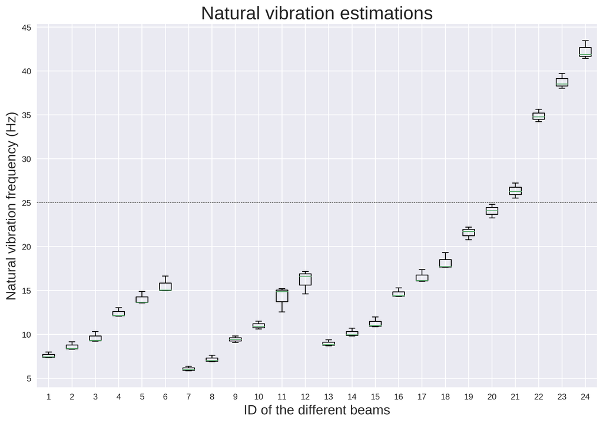

```python
plt.figure(figsize=(12,8), dpi=300)
plt.title("Natural vibration estimations",size=22)
plt.ylabel("Natural vibration frequency (Hz)",size=16)
plt.xlabel("ID of the different beams", size=16)
plt.gca().axhline(y=25, color='k', linewidth=0.5, linestyle="dashed")
# plt.gca().axvline(x=3.5, color='k', linewidth=0.5, linestyle="dashed")

plt.boxplot(values)
plt.show()
```

## Natural vibration frequency vs weight

We would now like to see clearly the different groups of materials used in our analysis. Since the two characteristics that are important to us are minimizing weight and keeping the natural vibration frequency above 25Hz, we use a frequency vs weight plot.

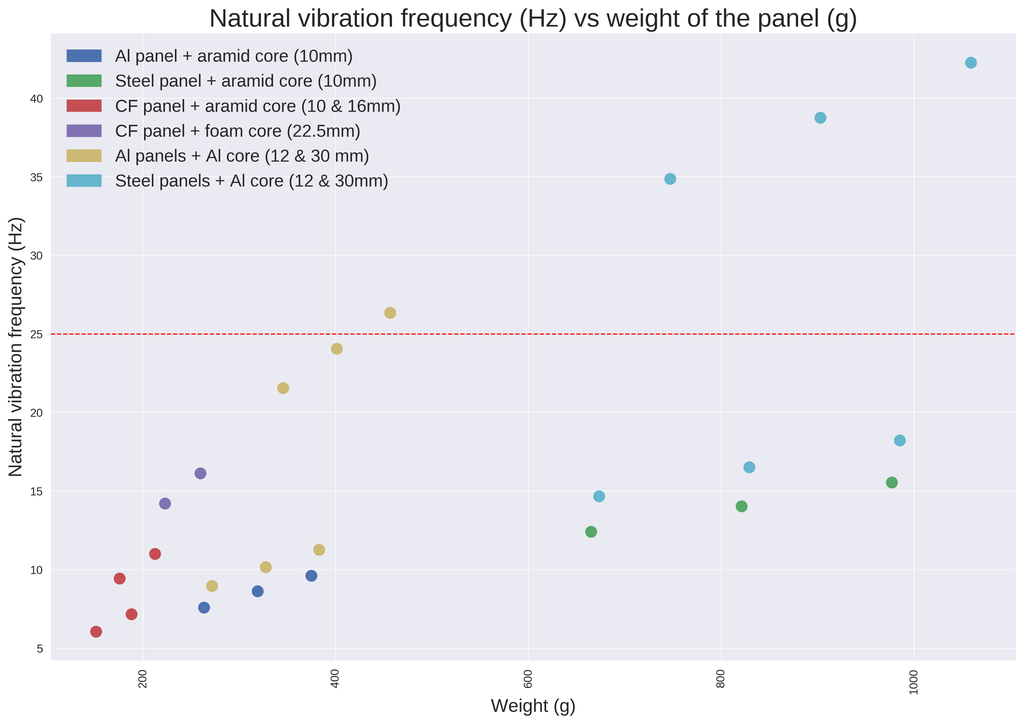

```python
tWeight = [i+5000 for i in weight]

fig = plt.figure(figsize=(15,10), dpi=300)
ax = plt.gca()

n=0
for grp in grpList:
    vibSlice=values[grp[0]:grp[1]+1]
    weightSlice = weight[grp[0]:grp[1]+1]
    ax.scatter(weightSlice, [np.mean(i) for i in vibSlice], s=100, color="C"+str(n), marker="o")
    n+=1
for grp in grpList_2:
    valSlice = [i for i in range(grp[0][0], grp[0][1]+1)]+[i for i in range(grp[1][0], grp[1][1]+1)]
    vibSlice = [values[i] for i in valSlice]
    weightSlice = [weight[i] for i in valSlice]
    ax.scatter(weightSlice, [np.mean(i) for i in vibSlice], s=100, color="C"+str(n), marker="o")
    n+=1
plt.ylabel("Natural vibration frequency (Hz)",size=16)
plt.xlabel("Weight (g)", size=16)
ax.grid(True, which="both", linewidth=0.5)
plt.gca().axhline(y=25, color='r', linewidth=1, linestyle="dashed")


# ax.set_yscale('log')
# ax.set_xscale('log')
# ax.set_ylim([0,180])
#foam core carbon fibre panels
# e1 = patches.Ellipse((320, 8), 250, 5,
#                  angle=0, linewidth=2, fill=False, color="C0")
# # #aramid core carbon fibre panels
# e2 = patches.Ellipse((850, 13), 450, 7,
#                  angle=0.5, linewidth=2, fill=False, color="C1")

# # # aluminium core
# e3 = patches.Ellipse((170, 17), 75, 13,
#                  angle=8, linewidth=2, fill=False, color="C2")
# # #aramid core carbon fibre panels
# e4 = patches.Ellipse((250, 27),100,10,
#                  angle=0.1, linewidth=2, fill=False, color="C3")
# # #aluminium core
# e5 = patches.Ellipse((2250, 15), 1500, 9,
#                  angle=0, linewidth=2, fill=False, color="C4")

# e6 = patches.Ellipse((5000, 35), 2000, 15,
#                  angle=0.1, linewidth=2, fill=False, color="C5")

# ellipseList = [e1,e2,e3,e4,e5,e6]

# for i in ellipseList:
#     ax.add_patch(i)

patchList = []
for i in range(6):
    patchList.append(patches.Patch(color='C'+str(i), label=titles[i]))

ax.xaxis.set_minor_formatter(FormatStrFormatter("%i"))
ax.yaxis.set_minor_formatter(FormatStrFormatter("%i"))

plt.setp(ax.xaxis.get_minorticklabels(), rotation=90, size=13)
plt.xticks(rotation="vertical")
plt.title("Natural vibration frequency (Hz) vs weight of the panel (g)", size=22)
plt.legend(handles=patchList, prop={'size': 15})
plt.show()
```

## Standard deviation of different groups

Since we can only test a total of 6 beams out of 24, we have to choose which one to use. By picking the one with the highest standard deviation for the different estimation methods in each material group, we can find which estimation method was the closest to the truth.

We can then use that estimation method to find the optimal panel dimensions after the testing is done.

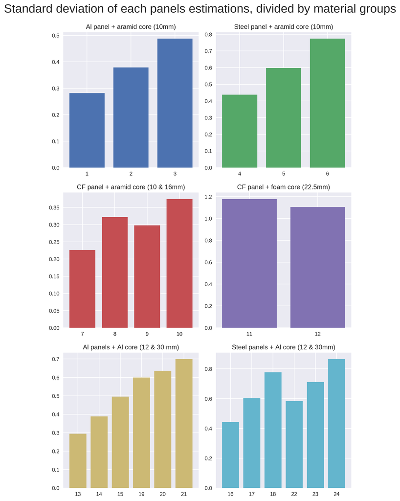

```python
grpList2 = [grp5,grp6]

f, axs = plt.subplots(3, 2,sharey="none", figsize=(8,13), dpi=300)
axs = axs.ravel()
stdList = []
n=0

for grp in grpList:
    vibSlice=values[grp[0]:grp[1]+1]
    weightSlice = weight[grp[0]:grp[1]+1]
    STD = [np.std(i) for i in vibSlice]
    stdList.append(STD)
    axs[n].bar(range(grp[0], grp[1]+1),STD,color="C"+str(n))
    axs[n].set_xticks(range(grp[0], grp[1]+1))
    axs[n].set_xticklabels([str(i+1) for i in range(grp[0], grp[1]+1)])
    axs[n].set_title(titles[n])
    ratio_default=(axs[n].get_xlim()[1]-axs[n].get_xlim()[0])/(axs[n].get_ylim()[1]-axs[n].get_ylim()[0])
    axs[n].set_aspect(ratio_default)
    n+=1

for grp in grpList_2:
    valSlice = [i for i in range(grp[0][0], grp[0][1]+1)]+[i for i in range(grp[1][0], grp[1][1]+1)]
    vibSlice = [values[i] for i in valSlice]
    weightSlice = [weight[i] for i in valSlice]
    STD = [np.std(i) for i in vibSlice]
    stdList.append(STD)
    axs[n].bar(range(len(valSlice)), STD,color="C"+str(n))
    axs[n].set_xticks(range(len(valSlice)))
    axs[n].set_xticklabels([str(i+1) for i in valSlice])
    axs[n].set_title(titles[n])
    ratio_default=(axs[n].get_xlim()[1]-axs[n].get_xlim()[0])/(axs[n].get_ylim()[1]-axs[n].get_ylim()[0])
    axs[n].set_aspect(ratio_default)
    n+=1

plt.suptitle("Standard deviation of each panels estimations, divided by material groups", size=22)
plt.tight_layout()
f.subplots_adjust(top=0.93)
plt.show()
```

So the panels that will be tested are **3, 6, 10, 11, 21 & 24.**

- 3 - Al panel (1.2mm) + Aramid core (10mm)
- 6 - Steel panel (1.2mm) + Aramid core(10mm)
- 10 - CF Panel (1mm) + Aramid core (16mm)
- 11 - CF Panel (0.75mm) + Foam core (22.5mm)
- 21 - Al panel (1.2mm) + Al core (30mm)
- 24 - Steel panel (1.2mm) + Al core (30mm)

```
(9.5, 0.015517)
(7.9, 0.011991)
(13.8, 0.009107)
```

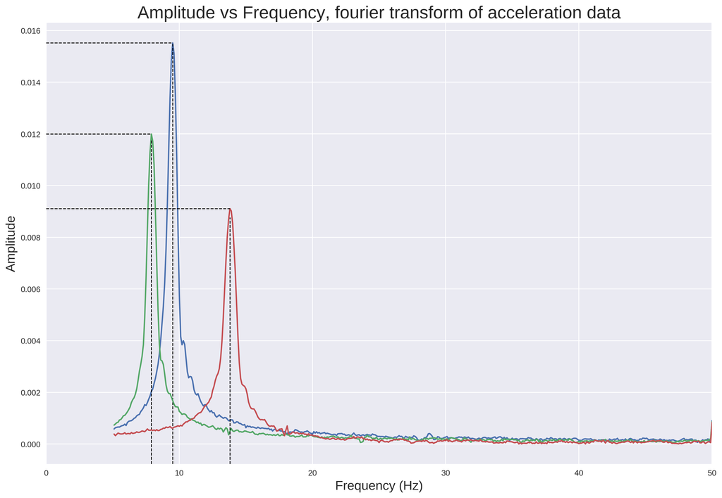

```python
panelTests = [3, 6, 10, 11, 15, 18, 21, 24]
valueDict = {}
mpl.rcParams.update(mpl.rcParamsDefault)
plt.style.use("seaborn")
for i in panelTests:
    for j in range(1,4):
        path = "E1E/Beam"+str(i)+"-"+str(j)

        key = str(i)+"-"+str(j)
        valueDict[key] = {'time':[], 'acceleration':[], 'frequency':[], 'amplitude':[]}

        with open(path, "r") as file:
            lines = file.readlines()

            for l in lines[1:10001]:
                lVal = l.strip().split("\t")
                valueDict[key]['acceleration'].append(float(lVal[1]))
                valueDict[key]['time'].append(float(lVal[0]))

            for l in lines[10053:]:
                lVal = l.strip().split("\t")
                valueDict[key]['amplitude'].append(float(lVal[1]))
                valueDict[key]['frequency'].append(float(lVal[0]))

def getMaxFreq(dictKey, plot=False):
    idx = dictKey["amplitude"].index(max(dictKey["amplitude"]))
    maxFreq = dictKey["frequency"][idx]
    maxAmp = dictKey["amplitude"][idx]
    if plot:
        plt.plot(dictKey["frequency"], dictKey["amplitude"])
        plt.xlim([0,50])
        ymin, ymax = plt.ylim()
        plt.gca().axvline(x=maxFreq, ymax= maxAmp/ymax, color="black", linewidth=1, linestyle="dashed")
        plt.gca().axhline(y=maxAmp, xmax=maxFreq/50, color="black", linewidth=1, linestyle="dashed")
    return maxFreq, maxAmp

plt.figure(figsize=(15,10), dpi=300)
print(getMaxFreq(valueDict["10-3"], plot=True))
print(getMaxFreq(valueDict["11-2"], plot=True))
print(getMaxFreq(valueDict["6-2"], plot=True))
plt.ylabel("Amplitude", size=16)
plt.xlabel("Frequency (Hz)", size=16)
plt.title("Amplitude vs Frequency, fourier transform of acceleration data", size=22)
plt.show()
```

```
{'3': [8.7, 8.7, 8.7], '6': [13.9, 13.8, 13.9], '10': [9.5, 9.5, 9.5], '11': [7.9, 7.9, 7.9], '15': [10.5, 10.5, 10.5], '18': [17.2, 17.2, 17.2], '21': [23.0, 22.5, 22.4], '24': [30.4, 30.0, 30.2]}
```

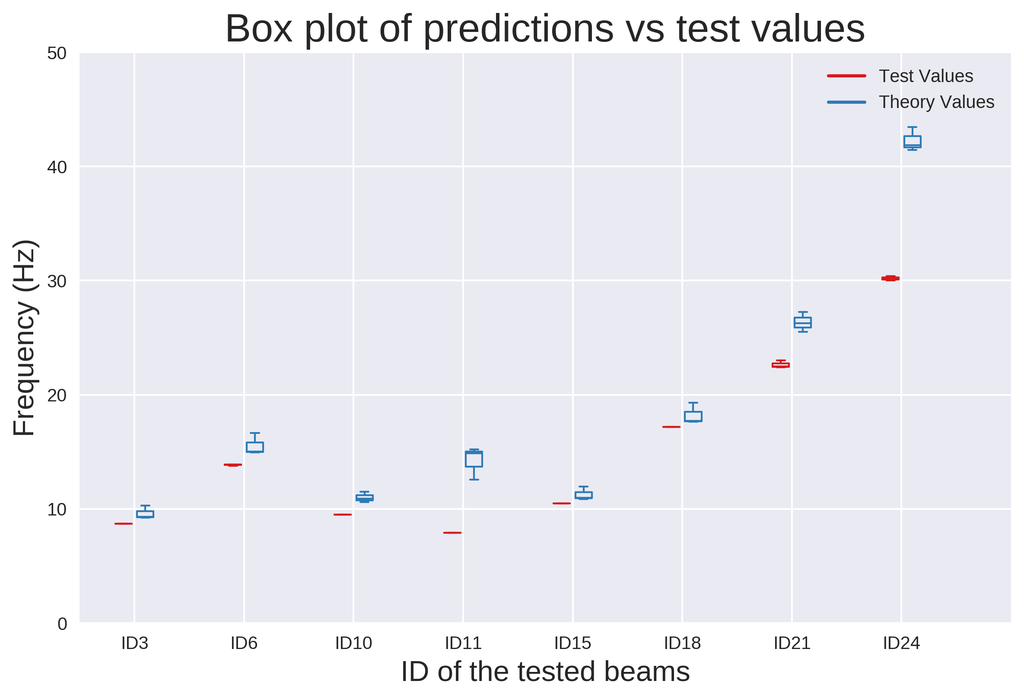

```python
def set_box_color(bp, color):
    plt.setp(bp['boxes'], color=color)
    plt.setp(bp['whiskers'], color=color)
    plt.setp(bp['caps'], color=color)
    plt.setp(bp['medians'], color=color)

freqDict = {}
for i in panelTests:
    freqDict[str(i)] = []
    for j in range(1,4):
        freqDict[str(i)].append(getMaxFreq(valueDict[str(i)+"-"+str(j)])[0])

print(freqDict)


ticks = ["ID"+str(i) for i in panelTests]

testValues = list(freqDict.values())
theoryValues = [values[i-1] for i in panelTests]

plt.figure(dpi=300)

bpl = plt.boxplot(testValues, positions=np.array(range(len(testValues)))*4.0-0.4, sym='', widths=0.6)
bpr = plt.boxplot(theoryValues, positions=np.array(range(len(theoryValues)))*4.0+0.4, sym='', widths=0.6)
set_box_color(bpl, '#D7191C') # colors are from http://colorbrewer2.org/
set_box_color(bpr, '#2C7BB6')

# draw temporary red and blue lines and use them to create a legend
plt.plot([], c='#D7191C', label='Test Values')
plt.plot([], c='#2C7BB6', label='Theory Values')
plt.legend()

plt.xticks(range(0, len(ticks) * 4, 4), ticks)
plt.xlim(-2, len(ticks)*4)
plt.ylim(0, 50)

plt.ylabel("Frequency (Hz)", size=16)
plt.xlabel("ID of the tested beams", size=16)
plt.title("Box plot of predictions vs test values", size=22)

plt.tight_layout()



plt.show()
```

```
[8.6999999999999993, 13.866666666666667, 9.5, 10.5, 17.199999999999999, 22.633333333333336, 30.199999999999999]
[0.8793538177860285, 0.70900676418377584, 0.9210743958313593]
```

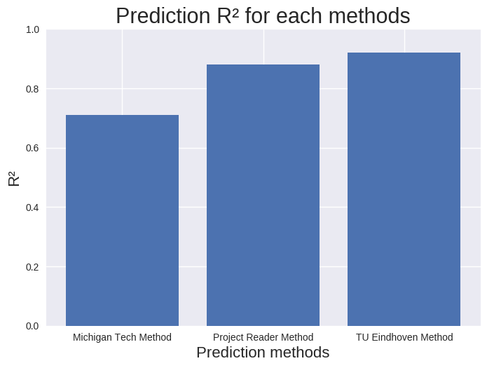

```python
from sklearn.metrics import r2_score

testMean = [np.mean(i) for i in testValues]
testMean.pop(3)
print(testMean)

r2List = []
for i in range(3):
    valSpec = [theoryValues[j][i] for j in range(len(theoryValues))]
    valSpec.pop(3)
    r2List.append(r2_score(testMean[:-1], valSpec[:-1]))

print(r2List)

plt.bar(["Project Reader Method", "Michigan Tech Method", "TU Eindhoven Method"], r2List)
plt.ylim([0,1])

plt.ylabel("R²", size=16)
plt.xlabel("Prediction methods", size=16)
plt.title("Prediction R² for each methods", size=22)

plt.show()
```

```
(30.4, 0.00141)
```

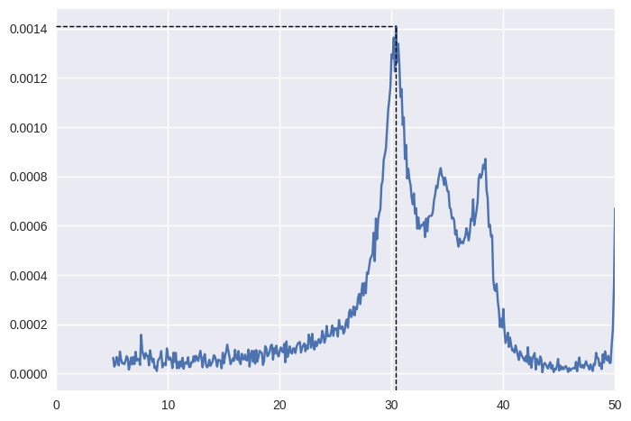

```python
plt.figure(dpi=300)

print(getMaxFreq(valueDict["24-1"], plot=True))
plt.show()
```